# Geo-Spatial sentiment analysis using Tweets related to the North Atlantic Treaty Organization (NATO)

# 3. Analysis

```r
library(quanteda)
library(quanteda.textplots)
library(cowplot)
library(vader)
library(readxl)
library(tidyverse)
#install.packages("grid", 'REdaS')
library(REdaS)
#geolocalization of cities from xxxx
setwd("D:/OneDrive - KU Leuven/COLLECTING BIG DATA SOCIAL SCIENCE/Project/as2/")
coordenates=read_excel("worldcities.xlsx", sheet = "coordenates")
coordenates$lat <- trimws(coordenates$lat, which = c("both"))
coordenates$lng <- trimws(coordenates$lng, which = c("both"))
head(coordenates,n = 2)
```

```
## # A tibble: 2 x 6
##   country city     ...3            city_ascii lat     lng
##   <chr>   <chr>    <chr>           <chr>      <chr>   <chr>
## 1 Austria Vienna   AustriaVienna   Vienna     48.2083 16.3725
## 2 Belgium Brussels BelgiumBrussels Brussels   50.8353 4.3314
```

```r
# collecting tweets by means of twitter api
#n=1000
#miles="50mi"
#search="nato"
#natotw <- data.frame()
#language="en"
#for (capital in coordenates$city_ascii){
#  city=coordenates %>% filter(city==capital) %>% select(country,lat, lng)
#  coord=paste(city$lat,",", city$lng, ",",miles)
#  coord=gsub(" ","",coord, fixed=TRUE)
#  tweets=search_tweets(q="nato",n, type="recent",geocode=coord, lang="en", include_rts = TRUE)
#  tweets$recol_id=city$country
#  natotw<- rbind(natotw,tweets) }


#saveRDS(natotw,file="C:/Users/rmara/OneDrive/Escritorio/Collecting Data")
#open tweets
natotw <- data.frame()
for (num in c(9,10,11,12)){
  natotw=rbind(natotw,readRDS(gsub(" ", "", paste("natotw_",num, ".rds"), fixed=TRUE)))}

head(natotw %>%select(text,recol_id))
```

```
## # A tibble: 6 x 2
##   text                                                                  recol_id
##   <chr>                                                                 <chr>
## 1 "@WhiteHouse Dear citizens of the USA, please stop all those horribl~ Austria
## 2 "@POTUS Dear citizens of the USA, please stop all those horrible agg~ Austria
## 3 "@jaccocharite And 16 NATO States bombed Tripolis for 48 hours witho~ Austria
## 4 "And yes, Turkey is still a member of NATO.\n\nSilence from Baghdad ~ Austria
## 5 "@fk_akis Turkey playing dirty games with everyone. With NATO, EU, w~ Austria
## 6 "@dinohealth @NATO To summarize:\n\n1. Turkey is the new Russia.\n2.~ Austria
```

*Step 2:* The tweets were cleaned using the following code. It is worth mentioning that Twitter user identifications were removed to protect their privacy. Besides, Countries having higher than 30 tweets were selected since it is the minimum amount of records to keep considering the Central Limit Theorem:

```r
# remove overlap between countries duplication
natotw=natotw %>% select(user_id, text, recol_id) %>% distinct(user_id, text, .keep_all = TRUE)
#clean tweets - reference: https://rstudio-pubs-static.s3.amazonaws.com/286190_fbd48f12527e41ecaf45437beec599df.html
natotw$plain2 = iconv(natotw$text, to = "ASCII", sub = " ")  # Convert to basic ASCII text to avoid silly characters
natotw$plain2 <- tolower(natotw$plain2)  # Make everything consistently lower case
natotw$plain2 <- gsub("@\\w+", " ", natotw$plain2)  # Remove user names
natotw$plain2 <- gsub("http.+ |http.+$", " ", natotw$plain2)  # Remove links
natotw$plain2 <- gsub("[[:punct:]]", " ", natotw$plain2)  # Remove punctuation
natotw$plain2 <- gsub("[ |\t]{2,}", " ", natotw$plain2)  # Remove tabs
natotw$plain2 <- gsub("amp", " ", natotw$plain2)  # "&" is "&amp" in HTML, so after punctuation removed ...
natotw$plain2 <- gsub("^ ", "", natotw$plain2)  # Leading blanks
natotw$plain2 <- gsub(" $", "", natotw$plain2)  # Lagging blanks
natotw$plain2 <- gsub(" +", " ", natotw$plain2) # General spaces (should just do all white spaces no?)
natotw=natotw %>% distinct(text, .keep_all = TRUE) # remove duplicates
head(natotw %>% select(text,plain2))
```

```
## # A tibble: 6 x 2
##   text                                    plain2
##   <chr>                                   <chr>
## 1 "@WhiteHouse Dear citizens of the USA,~ "dear citizens of the usa please stop~
## 2 "@POTUS Dear citizens of the USA, plea~ "dear citizens of the usa please stop~
## 3 "@jaccocharite And 16 NATO States bomb~ "and 16 nato states bombed tripolis f~
## 4 "And yes, Turkey is still a member of ~ "and yes turkey is still a member of ~
## 5 "@fk_akis Turkey playing dirty games w~ "turkey playing dirty games with ever~
## 6 "@dinohealth @NATO To summarize:\n\n1.~ "to summarize \n\n1 turkey is the new~
```

```r
#total tweets per country
tot_tw_country=natotw %>% group_by(recol_id) %>% summarise(total=n()) %>% arrange(-total)
head(tot_tw_country, 5)
```

```
## # A tibble: 5 x 2
##   recol_id total
##   <chr>    <int>
## 1 England    999
## 2 Belgium    803
## 3 Germany    360
## 4 Ireland    284
## 5 France     266
```

```r
# contries having lower than 30 tweets are deleted - Slowakia, Iceland, Cyprus
natotw=natotw %>% filter(!recol_id %in% c("belarus","Slovakia", "Iceland", "Cyprus"))
```

*Step 3:* The compound, positive, negative, and neutral sentiment scores were computed per each tweet. The median is computed since the histograms (see in the statistical section) depict skew distributions.

```r
#compute sentiment analysis using vader
sentiment=cbind(natotw,vader_df(natotw$plain2)[3:6])

sentiment=sentiment %>% filter(!is.na(sentiment$compound)) #1 tweet with error deleted
```

```r
#compute average compound
average_sentiment=sentiment %>% group_by(recol_id) %>% summarize(med_compound= median(compound), med_pos= median(pos), med_neg=median(neg), med_neu=median(neu))
```

*Step 4:* The distance between the European countries and Russia is computed by using the Haversine formula, which is the shortest distance between two points on a sphere (or the surface of Earth).

```r
distance=function(lat1, lat2, lon1, lon2){
lon1 = deg2rad(lon1)
lon2 = deg2rad(lon2)
lat1 = deg2rad(lat1)
lat2 = deg2rad(lat2)
# Haversine formula
dlon = lon2 - lon1
dlat = lat2 - lat1
a = sin(dlat / 2)**2 + cos(lat1) * cos(lat2) * sin(dlon / 2)**2
c = 2 * asin(sqrt(a))
# Radius of earth in kilometers. Use 3956 for miles
r = 6371
# calculate the result
return(c * r) }
# driver code
lat_Moscow = 55.7522200
lon_Moscow = 37.6155600
coordenates$lat=as.numeric(coordenates$lat)
coordenates$lng=as.numeric(coordenates$lng)
# compute distance in the df
coordenates$distance <- round(mapply(distance,lat_Moscow, coordenates$lat, lon_Moscow, coordenates$lng),0)
#to merge pos, neg, neu to coordinate df
polarity_country=coordenates %>% merge(average_sentiment,by.x = "country", by.y =  "recol_id")
```

# 4. Results

To begin with, we plot a word cloud to identify the words that are related the most to NATO. We remove words like (“nato”, “#nato”, “@nato”, “amp”). The most relevant words are *Ukraine, Finland, war, support, military, security*, and *join.*

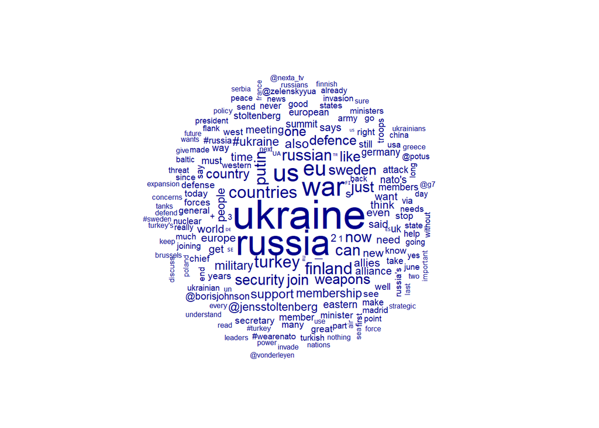

```r
mystopwords = stopwords("english",
                        source="snowball")
mystopwords = c("nato", "#nato", "@nato","amp", mystopwords)

d = corpus(natotw$text) %>%
  tokens(remove_punct=T) %>%
  dfm() %>%
  dfm_remove(mystopwords)
textplot_wordcloud(d, max_words=180, adjust = 0)
```

Moreover, In order to answer whether the distance between European countries and Russia plays a role in the sentiments towards NATO, we build histograms of the polarity compound score by country. The histograms show high dispersion and skew curves, which means that there is a high heterogeneity when it comes to the sentiments towards NATO among countries.

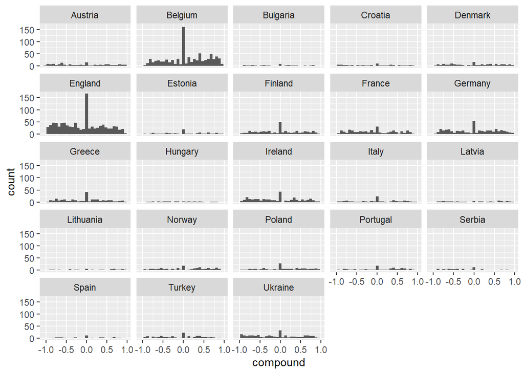

```r
#histogram per country
ggplot(sentiment,aes(x=compound)) +geom_histogram() + facet_wrap(~recol_id)
```

Furthermore, we computed the median of the compound score to check the relationship between the sentiment’s polarity and distance. We found no evident relationship between these two. However, we find a negative relationship between the median of positive sentiment score (tweets with positive sentiments towards NATO) and distance. This means that the closer a country is to Russia, the more it tweets positively about NATO, which confirms our hypothesis.

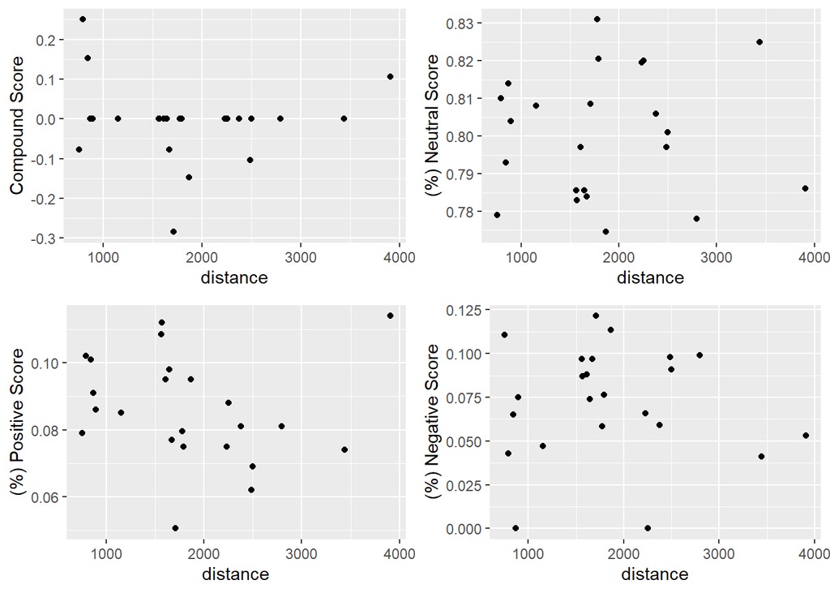

```r
#scatter plots
a=ggplot(polarity_country, aes(x=distance, y=med_compound)) + geom_point() +ylab("Compound Score")
b=ggplot(polarity_country, aes(x=distance, y=med_neu)) + geom_point() +ylab("(%) Neutral Score")
c=ggplot(polarity_country, aes(x=distance, y=med_pos)) + geom_point() +ylab("(%) Positive Score")
d=ggplot(polarity_country, aes(x=distance, y=med_neg)) + geom_point() +ylab("(%) Negative Score")
plot_grid(a, b,c,d, ncol = 2, nrow = 2)
```

```r
z_pol<-scale(polarity_country %>%filter(distance<3600) %>%  select(distance, med_compound, med_pos, med_neg, med_neu) ,center=TRUE,scale=TRUE)
round(cor(z_pol),2)
```

```
##              distance med_compound med_pos med_neg med_neu
## distance         1.00        -0.25   -0.44    0.05    0.18
## med_compound    -0.25         1.00    0.59   -0.53    0.18
## med_pos         -0.44         0.59    1.00   -0.23   -0.35
## med_neg          0.05        -0.53   -0.23    1.00   -0.65
## med_neu          0.18         0.18   -0.35   -0.65    1.00
```

According to Cohen’s (1988) [7], a correlation larger than 50% is considered to have a large effect size. Therefore, *the median of positive emotion* and *distance* seems to have a negative medium-size effect. This means that as the distance between a country and Russia decreases, the higher positive words related to NATO are found.

Finally, a map of Europe is shown to provide a general idea about *the median of positive sentiments* in the European region.

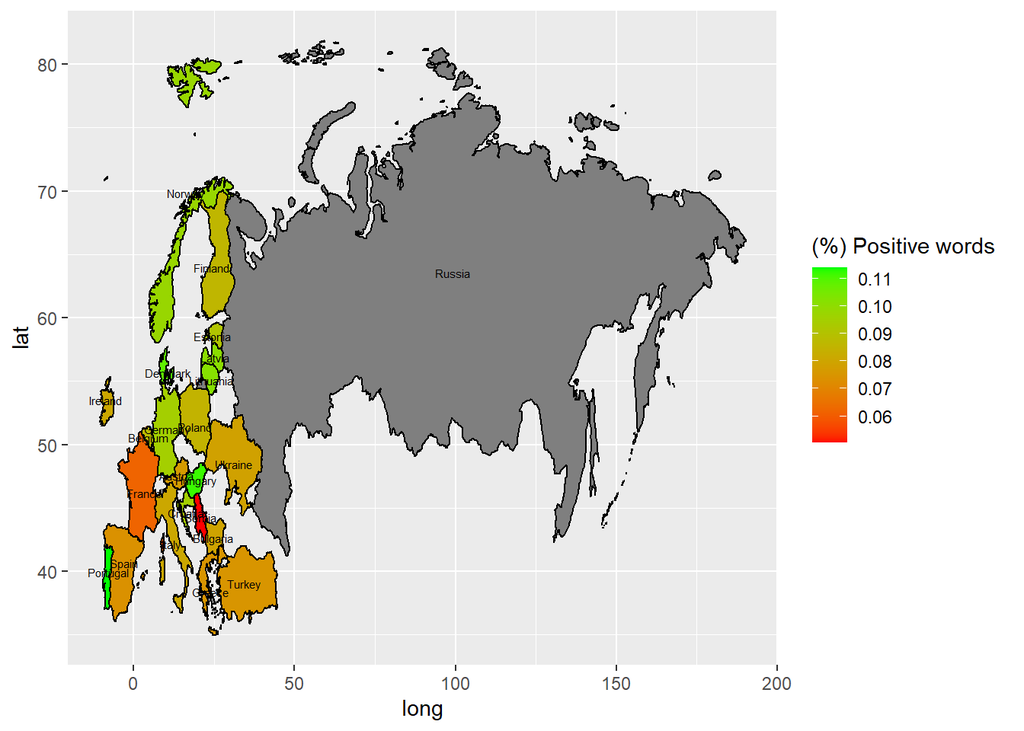

```r
polarity=polarity_country %>% select(country,med_compound, med_pos, med_neg, med_neu)
polarity=rbind(polarity, data.frame(country="Russia", med_compound=0, med_pos=0, med_neg=0, med_neu=0))
mapdata= map_data("world")
mapdata=left_join(mapdata,polarity, by=c("region"= "country"))
mapdata2=mapdata %>% filter(!is.na(mapdata$med_compound))
mapdata2$med_compound[mapdata2$region=="Russia"]=NA
mapdata2$med_pos[mapdata2$region=="Russia"]=NA
mapdata2$med_neg[mapdata2$region=="Russia"]=NA
mapdata2$med_neu[mapdata2$region=="Russia"]=NA
# add country names
countries=mapdata2 %>% group_by(region) %>% summarise(long=mean(long), lat=mean(lat))

#compound
ggplot(mapdata2, aes(long, lat)) +  geom_polygon(aes(group=group ,fill=med_pos), colour='black') +
  scale_fill_gradient(name= "(%) Positive words ", low='red', high='green', na.value="grey50")+
  geom_text(data=countries, aes(long, lat, label = region), size=2)
```